# Classification of titanic data

Vladislav Brion

19 October, 2020

This report contains results of applying logistic regression classifier to titanic data. Quality of survival outcome predictions is outlined.

### The data

#### Data cleaning and initial predictor selection

Table 1. Attributes of original titanic data

| Attribute | Type | Description |
| --- | --- | --- |
| pclass | numeric | Passenger class (1 = 1st; 2 = 2nd; 3 = 3rd) |
| survived | numeric | the passenger survived or not (0 = No; 1 = Yes) |
| name | character | title and family names |
| sex | character | male/female |
| age | numeric | Age, a significant portion of values are missing |
| sibsp | numeric | Number of siblings/spouses aboard |
| parch | numeric | Number of parents/children aboard |
| ticket | character | Ticket number |
| fare | numeric | Passenger fare (British Pound) |
| cabin | character | Location of the cabin |
| embarked | character | Port of embarkation (C = Cherbourg; Q = Queenstown; S = Southampton) |
| boat | character | Lifeboat (if survived) |
| body | numeric | Body number (if did not survive and body was recovered) |
| home.dest | character | Home/destination |

The survived binary variable (0 - not survived; 61.8% observations, and 1 - survived; 38.2% observations) is used as an outcome for all models, whereas other variables can be considered as candidates for predictors. The boat and body variables depend on surviving and could not be considered as predictors. The ticket variable contains digits and possible letters. Without meaning of its cotnent this variable could not be considered as possible predictor. I found a pattern that persons within one family had the same ticket number. It could be useful if a family as a group of people was introduced into the model. Also, grouping people into their families could help to imputation of missing age and updating incorrect values of the number of siblings/spouses, as well as the number of parents/children (if these numbers are incorrect). However, this analysis was out of this report, and, as a result, the ticket variable was removed.

The name variable having a pattern “Master” corresponds to a male child. It could be used for imputation of missing age records. The home.dest variable containing a city and country/state name could provide information about person’s wealth which could be an additional factor of surviving. However, there are approximately 332 cities, and criteria of their grouping is unknown. Both of the variables will probably be analysed in the further reports. Currently, they were removed from the model.

The cabin variable is replaced by cabinFirstLetter variable consisting of the first letter of the cabin. This letter can contain additional information about class or location of a cabin.

Table 2 shows number of missing values in the dataset.

Table 2. Counts of missing values

| Variable | missing counts |
| --- | --- |
| pclass | 0 |
| survived | 0 |
| sex | 0 |
| age | 263 |
| sibsp | 0 |
| parch | 0 |
| fare | 1 |
| embarked | 2 |
| cabinFirstLetter | 1014 |

#### Transformation of predictors

The cabinFirstLetter variable has missig records. This number is large, and this variable can’t be efficiently used without imputation. It can be used together with the pclass variable, as shown on the table below.

Table 3. Counts of pclass and cabin factors

| pclass | cabinFirstLetter | counts |
| --- | --- | --- |
| 1 | A | 22 |
| 1 | B | 65 |
| 1 | C | 94 |
| 1 | D | 40 |
| 1 | E | 34 |
| 1 | T | 1 |
| 1 | NA | 67 |
| 2 | D | 6 |
| 2 | E | 4 |
| 2 | F | 13 |
| 2 | NA | 254 |
| 3 | E | 3 |
| 3 | F | 8 |
| 3 | G | 5 |
| 3 | NA | 693 |

This variable can’t be used for splitting levels pclass = 2 or 3 due to majority of its missing values. On the other side, the level pclass = 1 can be possibly split on multiple levels depending on the cabinFirstLetter values. I don’t want to split it onto many levels with non-frequent counts. The split can be performed using the table below:

Table 4. Counts of pclass = 1, cabin and survived factors

| pclass | cabinFirstLetter | survived | counts |
| --- | --- | --- | --- |
| 1 | A | 0 | 11 |
| 1 | A | 1 | 11 |
| 1 | B | 0 | 18 |
| 1 | B | 1 | 47 |
| 1 | C | 0 | 37 |
| 1 | C | 1 | 57 |
| 1 | D | 0 | 12 |
| 1 | D | 1 | 28 |
| 1 | E | 0 | 10 |
| 1 | E | 1 | 24 |
| 1 | T | 0 | 1 |
| 1 | NA | 0 | 34 |
| 1 | NA | 1 | 33 |

The fare variable contains 17 zero records which were considered as incorrect and one missing record. I imputed them using the median fare of the corresponding pclass. The histogram of the imputed fare is shown below.

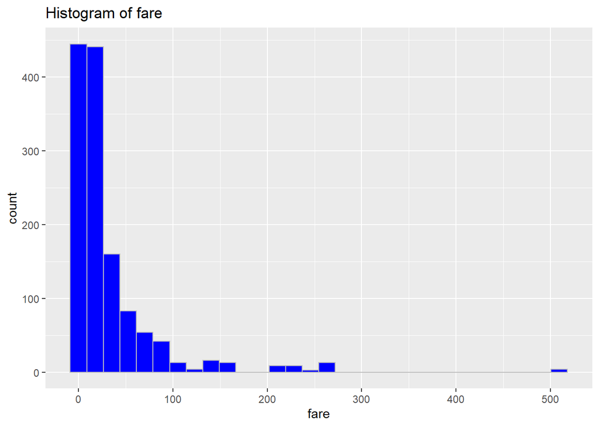

The distribution of the fare is right skewed. Also, some records exceeding 500 can possibly be outliers. Due to abcense of additional information about the fare I decided to keep these values and perform logarithmic transformation to the fare predictor. As a result, impact of the large records was decreased.

The distribution of the sibsp and parch are also right skewed and some records can be outliers, as shown on plot below:

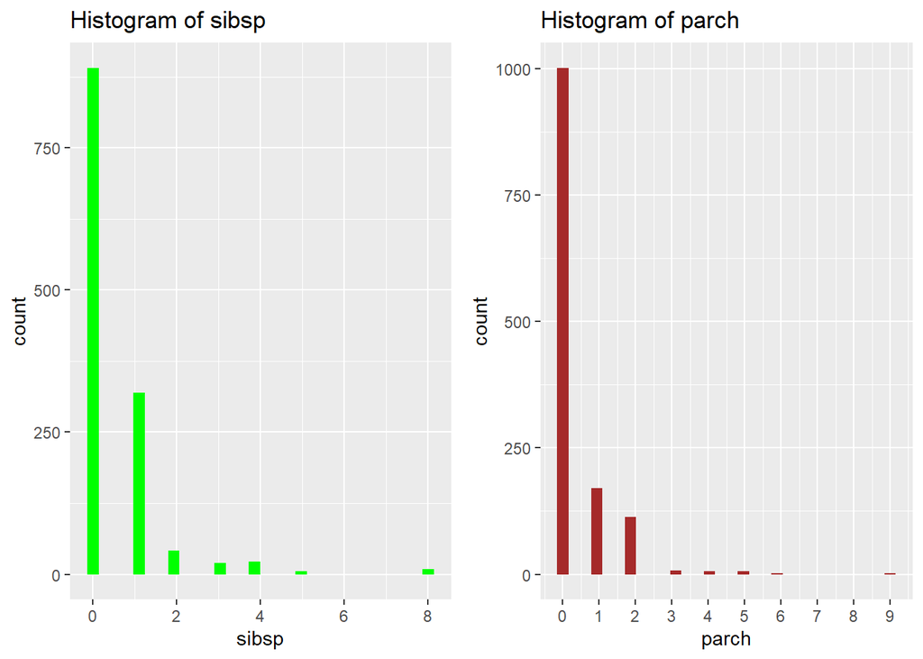

The large values of these two variables have very low counts, and, therefore, should not significantly impact on quality of the analysis. I decided to keep the both of these variables as predictors in an initial model. Instead, they could be used for creating a new predictors describing an indicator of a family and its size. Such predictors could be included into a hierarchical model. However, this idea was not implemented in this report.

The age variable contains 263 missing records. It is relatively large number, and imputation of these missing values were not part of this report. The following two models can be considered:

1. Model containing the age variable. Some models won’t consider missing records, that cause to lower number of observations, and, as a result, reduced quality of the analysis.
2. The age variable is excluded from the model. This model will contain more records. However, the age variable may be important predictor. As a result, omitting this variable would also decrease the quality of analysis.

I started my analysis from the first model which is more general. As for other predictors, keeping the age predictor will be analysed during finding the best set of predictors for logistic regression. An initial model contains the following predictors:

- Qualitative predictors: pclass, sex, embarked;
- Numerical predictors age, fare, sibsp, parch.

Two missing embarkedvalues records won’t impact on the model.

#### Correlation of predictors

The numerical predictors aren’t highly correlated. Their maximum pairwise correlation coefficient is 0.37. However, multicollinearity in the model can exist. It can impact on results of logistic regression. Creating a reduced model based on lower number of predictors will be analysed in this report.

### Deviance of logistic regression

Similar to the R square value for linear regression, deviance describes a fit quality of logistic regression. The value of deviance of given model is proportional to difference of the log-MLEs of the saturated and this model. The saturated model is the perfect model, and its MLE value is always higher than MLE values of other models. Then the value of deviance is always non-negative, and a low deviance of a model corresponds to good fit because this model is close to the perfect model.

In order to evaluate goodness of fit of proposed model, two deviances are considered:

- Residual deviance is the deviance of the proposed model.
- Null deviance is the deviance of the null model (intercept only).

The residual deviance corresponding to a model with at least one predictor is lower then the null deviance. Their difference shows an explained deviance of the proposed model. Larger difference outlines how the fit of the proposed model is better than the fit of the null model. The summary of anova is shown below.

Comparison of the null model (first row) and proposed model (second row)

| Resid. Df | Resid. Dev | Diff Df | Diff Deviance | Pr(>Chi) |
| --- | --- | --- | --- | --- |
| 1043 | 1411.0311 |  |  |  |
| 1034 | 954.1247 | 9 | 456.9065 | 0 |

The deviance of the initial model is significantly lower than one for the null model. The p-value is very low. Then, we can reject the corresponding null hypothesis, and conclude that this model fits the data better compared to the null model. However, the McFadden’s r square coefficient which outlines an explained deviance of the model is 0.324. This value is relatively low and it will be decreased after removal of some non-significant predictors. As a result, fit of the existing model of logistic regression is not good, that can reduce quality of prediction. On the other hand, I accepted this value, and the quality of classification can be evaluated by misclassification errors on testing set.

In order to find the optimal set of predictors and reduce possible overfitting, I used the stepwise logistic regtression. Due to low number of possible predictors, the initial model run very fast, and the backward approach was selected. Starting from this model, I reduced each single predictor and selected the current best model based on an information criteria.

Coefficients of the logistic regression correspond to maximum value of likelihood function. Then, a low value of residual deviance which is proportional to negative log-likelihood value corresponds to a good fit. However, adding more predictors will always improve a fit. Then, larger number of predictors should be penalized. The Akaike information criteria (AIC) is the sum of the residual deviance and the double number of predictors. As a result, adding predictors which do not significantly improve the fit can make the model worse. For a single iteration of the backward stepwise regression, a predictor is selected to be removed when the corresponding model has the lowest AIC value. The itertation process of removing a single variable continues until the model with maximum predictors at current iteration is the best. In other words, further omitting of any predictor increases the AIC.

### Classification methods

The current version of report considers classification based on logistic regression. The classification is based on assumption that both of the possible misclassification errors have equal importance.

As for each classification method, the dataset was randomly split on training set (80% of observations) which was used for creating a predictor, and on testing set (20% of observations) which was used for quality evaluation of the predictor. The predictors were applied on the testing set, and the predicted outcomes were compared with actual outcomes in this set.

For classification of a binary variable a cut-off value should be set. All predicted outcomes below the cut-off value are assigned to the class survived = 0, and those exceeding this value are assigned to the class survived = 1. The default value for most of classification methods is 0.5. It is often used when both of misclassification errors are treated equally.

Accuracy which is the overall ratio of correct predictions (for both outcome classes) is the main indicator of the quality of classification. However, misclassification consists of two types of errors (FN - false negative and FP - false positive). Values of each error are also indicate the prediction quality. When data is imbalanced or both of the misclassification errors have different importance, the cut-off value can be different from 0.5. The titanic data can be considered as balanced because proportions of two outcomes are not significantly different. An alternative cut-off values based on ROC curve are analysed below.

### ROC curve

For a model with only two outcome classes, a receiver operating characteristic curve (ROC) provides description of classification quality. ROC is a plot of the true positive rate (TPR) against the false positive rate (FPR) for different cut-off values. The area under the curve (AUC) describes the quality of prediction. The point (0, 1) is an asymptotic best point, and the AUC for the asymptotically best curve is equal to 1.

ROC analysis can be used for evaluation an optimal cut-off value. These value can be obtained from optimization of various functions of TPR and FPR. One of the following functions can be considered:

- minimum distance from the curve to the point (0, 1). This function is defined as sum of squares of 1 - TPR and FPR.
- maximum of Youden index which is TPR - FPR.

Another criterion is minimization of the total misclassification error that is maximal accuracy. For titanic data, the maximal accuracy is obtained at cut-off value = 0.61.

The next plot shows the ROC curve for the logistic regression predictor. The AUC is 0.86.

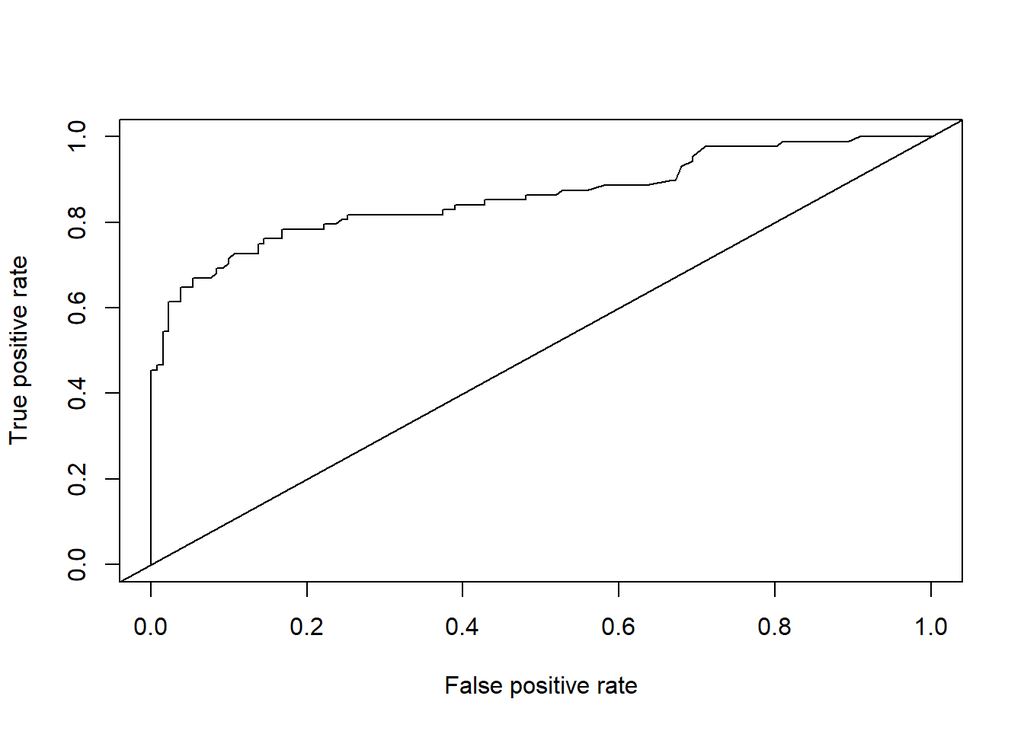

### Quality of logistic regression classification for titanic data

The result can depend on split onto the training and testing set.

I created 20 different splits onto two sets in order to produce summary of predictor quality based on multiple splits.

Summary of the values describing quality of prediction is shown on table below.

Table 5. Accuracy of logistic regression predictor

|  | min | mean | st deviation | max |
| --- | --- | --- | --- | --- |
| training | 0.79 | 0.8 | 0.007 | 0.82 |
| testing | 0.74 | 0.8 | 0.024 | 0.84 |

### Alternative analysis: shrinkage methods

These methods shrink some of the regression coefficients towards zero. They add small bias to the model and minimize slightly different functions. The resulted models may have lower variance. The main srinkage methods are lasso and ridge regression. The lasso has more strict shrinkage. I applied both of these methods as well as a mixed method to an initial model. These methods do not accept categorical variables. Thus, I converted each of them to k - 1 independent binary columns where k is the number of levels in the corresponding categorical variable. Also, all rows with at least one missing value had to be removed. I considered two data sets: with age predictor and without it, as it was explained above. ROC and the corresponding optimal cut-off values were produced for each case.

Summary of the values describing quality of prediction (testing set) of the shrinkage methods is shown on table below. The case alpha = 0 corresponds to the ridge regression, whereas alpha = 1 corresponds to the lasso regression, and alpha = 0.5 belongs to the elastic net.

Table 6. Quality of predictors based on shrinkage methods

|  | min | mean | st deviation | max |
| --- | --- | --- | --- | --- |
| Model with age Alpha0 | 0.78 | 0.81 | 0.025 | 0.86 |
| Model with age Alpha0.5 | 0.78 | 0.81 | 0.021 | 0.84 |
| Model with age Alpha1 | 0.76 | 0.81 | 0.021 | 0.84 |
| Model without age Alpha0 | 0.76 | 0.80 | 0.020 | 0.84 |
| Model without age Alpha0.5 | 0.76 | 0.80 | 0.016 | 0.82 |
| Model without age Alpha1 | 0.76 | 0.79 | 0.015 | 0.82 |

### Conclusions and further steps for improvement of prediction accuracy

Imputation of missing age values will increase number of observations used in the analysis and can improve quality of prediction. Also, a hierarchical model described above can be analysed.